# HyperParameter Optimisation

## Introduction

This notebook documents my attempt to use **amortized neural posterior estimation** for Bayesian inference in a Gamma model, focusing on the challenges and surprises encountered — even when using sufficient statistics.

Initially, I struggled to obtain reliable posterior approximations when conditioning on traditional summary statistics (such as mean and variance). Hoping for improvement, I turned to **exact sufficient statistics**—specifically, the sum and sum of logarithms of the observations—for the Gamma$(\alpha, \beta)$ model. Given the sufficiency property, one might expect this to greatly simplify neural posterior learning.

However, I was surprised to find that even with sufficient statistics, **amortized neural networks often performed very poorly and showed instability** in learning the true posterior, even with large simulated datasets. The networks were miscentered and extremely varied, simply failing to capture the true posterior shape.

This failure motivated a deeper investigation into the **role of hyperparameter optimization**.

- We set up the Bayesian inference problem and generated simulated data,
- Analytical calculation of the true posterior to serve as a reference,
- Construction of a large amortization dataset using sufficient statistics,
- Careful normalization and neural network modeling,
- Visualization and diagnosis of instability and poor fits,
- Progressive application of Bayesian hyperparameter optimization (with Optuna’s TPE) to search for well-performing neural architectures and training settings,
- The resulting improvement in posterior approximation as we scale up hyperparameter search.

So it's a bit of a cautionary tale: even with sufficient statistics, **careful tuning and diagnostics are essential** for reliable neural inference.

```python
# ========== Imports ==========

import numpy as np                  # For numerical operations
import torch                         # For PyTorch operations
import torch.nn as nn                # Neural network layers
import torch.nn.functional as F

import torch.optim as optim          # Optimizers
import optuna                        # Hyperparameter optimization library
from sklearn.model_selection import train_test_split  # For splitting data
from sklearn.metrics import mean_squared_error  # For evaluating model performance

import matplotlib.pyplot as plt       # For plotting
import random                        # For setting seeds

from scipy.special import gammaln

# ========== Seed Setup (for reproducibility) ==========
random.seed(0)
np.random.seed(0)
torch.manual_seed(0)

# ========== Optuna Setup ==========
# This sets the study direction for Optuna to minimize the objective function (e.g., loss function)
study = optuna.create_study(direction='minimize')
```

```
[I 2025-08-02 11:37:01,155] A new study created in memory with name: no-name-4b27a530-3db7-4571-8fb2-2234072a4271
```

### Generate Observed Data

We begin by simulating our observed data.  
We draw 100 independent samples from a Gamma distribution with shape parameter $\alpha=2$ and scale parameter $\beta=1$.

```
First 10 observations:  [5.13882958 2.23848091 5.42713227 0.69658644 1.53693153 2.25493003
 2.85486696 1.82873505 2.30787192 2.13561703]
```

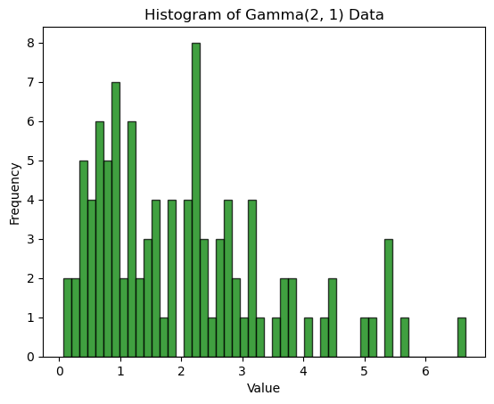

```python
# ========== Generate Observed Data ==========

# Parameters for Gamma distribution (alpha=2, beta=1)
alpha = 2  # shape parameter (alpha)
beta = 1   # scale parameter (beta)

# Generate 100 iid observations from Gamma(alpha, beta)
data = np.random.gamma(alpha, beta, 100)

# Display the first few observations
print("First 10 observations: ", data[:10])

# Optionally, you can also plot the data distribution
import matplotlib.pyplot as plt
plt.hist(data, bins=50, alpha=0.75, color='green', edgecolor='black')
plt.title('Histogram of Gamma(2, 1) Data')
plt.xlabel('Value')
plt.ylabel('Frequency')
plt.show()
```

### Set Priors for $\alpha$ and $\beta$

We specify **independent exponential priors** for both the shape parameter $\alpha$ and scale parameter $\beta$: [ \alpha \sim \mathrm{Exp}(1), \qquad \beta \sim \mathrm{Exp}(1) ] A sample of each prior is shown below, along with their histograms.  
These priors are broad and weakly informative, placing most probability mass on small positive values (as is typical for exponential distributions).

```
First 10 alpha prior samples:  [0.23252501 0.55283838 0.46867648 0.62282931 0.32521602 0.88378566
 1.99403924 0.12503259 0.72852383 0.14164203]
First 10 beta prior samples:  [1.50821523 1.50241281 0.30032508 0.46810645 0.88576064 0.31858386
 0.46339003 0.21946816 0.61591929 0.04563805]
```

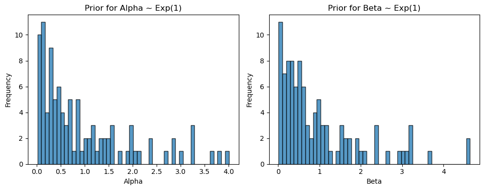

```python
# ========== Set Priors for Alpha and Beta ==========

# Number of prior samples (you can change this if needed)
num_samples = 100

# Prior: alpha ~ Exp(1), beta ~ Exp(1), iid
alpha_prior = np.random.exponential(scale=1.0, size=num_samples)
beta_prior  = np.random.exponential(scale=1.0, size=num_samples)

# Display the first few samples
print("First 10 alpha prior samples: ", alpha_prior[:10])
print("First 10 beta prior samples: ", beta_prior[:10])

# Optionally, plot histograms of the priors
import matplotlib.pyplot as plt

plt.figure(figsize=(10,4))

plt.subplot(1,2,1)
plt.hist(alpha_prior, bins=50, alpha=0.75, edgecolor='black')
plt.title('Prior for Alpha ~ Exp(1)')
plt.xlabel('Alpha')
plt.ylabel('Frequency')

plt.subplot(1,2,2)
plt.hist(beta_prior, bins=50, alpha=0.75, edgecolor='black')
plt.title('Prior for Beta ~ Exp(1)')
plt.xlabel('Beta')
plt.ylabel('Frequency')

plt.tight_layout()
plt.show()
```

### Compute True Posterior via Grid Approximation

To obtain a reference for model evaluation, we calculate the **exact posterior** for $(\alpha, \beta)$ given the observed data and exponential priors.  
The posterior is computed analytically up to normalization, using a dense grid over possible $(\alpha, \beta)$ values.

The marginal posteriors $p(\alpha\,|\,y)$ and $p(\beta\,|\,y)$ are then obtained by integrating (summing) over the grid.  
These serve as the "ground truth" for later comparison with neural network-based approximations.

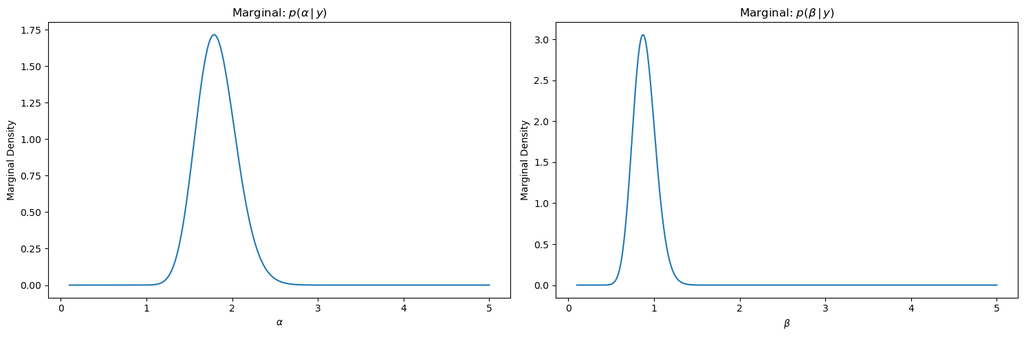

```python
# Observed data
y = data
n = len(y)
sum_y = np.sum(y)
sum_log_y = np.sum(np.log(y))

# Grid for alpha and beta
alpha_grid = np.linspace(0.1, 5, 600)
beta_grid = np.linspace(0.1, 5, 600)
A, B = np.meshgrid(alpha_grid, beta_grid, indexing='ij')

# Log unnormalized posterior
log_post = (
    (A - 1) * sum_log_y      # sum log(y_i) * (alpha - 1)
    - B * sum_y              # beta * sum y_i
    - n * gammaln(A)         # -n * log Gamma(alpha)
    + n * A * np.log(B)      # +n*alpha*log(beta)
    - A - B                  # Exponential priors
)

# Normalize for stability
log_post -= np.max(log_post)
post = np.exp(log_post)
post /= np.sum(post)  # Normalize

# Compute grid spacing
d_alpha = alpha_grid[1] - alpha_grid[0]
d_beta = beta_grid[1] - beta_grid[0]

# Marginals (unnormalized)
alpha_marginal = np.sum(post, axis=1) * d_beta
beta_marginal  = np.sum(post, axis=0) * d_alpha

# Properly normalize to area = 1
alpha_marginal /= np.trapz(alpha_marginal, alpha_grid)
beta_marginal  /= np.trapz(beta_marginal, beta_grid)

# ========== Plot ==========
plt.figure(figsize=(15, 5))

plt.subplot(1,2,1)
plt.plot(alpha_grid, alpha_marginal)
plt.xlabel(r'$\alpha$')
plt.ylabel('Marginal Density')
plt.title('Marginal: $p(\\alpha\,|\,y)$')

plt.subplot(1,2,2)
plt.plot(beta_grid, beta_marginal)
plt.xlabel(r'$\beta$')
plt.ylabel('Marginal Density')
plt.title('Marginal: $p(\\beta\,|\,y)$')

plt.tight_layout()
plt.show()
```

### Simulate Datasets for Amortized Inference

We generate $10^6$ synthetic datasets by:

- Sampling $(\alpha, \beta)$ pairs from the prior,
- Simulating $n=100$ observations from each Gamma$(\alpha, \beta)$,
- Calculating the sufficient statistics: $\sum y$ and $\sum \log y$.

This creates a large training set mapping sufficient statistics to their corresponding $(\alpha, \beta)$, used for training the amortized neural network posterior later.

```python
N_sim = 1_000_000
N_obs = 100

alphas = np.random.exponential(scale=1.0, size=N_sim)
betas  = np.random.exponential(scale=1.0, size=N_sim)

# Generate all samples at once (shape: N_sim x N_obs)
Y = np.random.gamma(alphas[:, None], betas[:, None], (N_sim, N_obs))
Y = np.clip(Y, 1e-12, None)  # Prevent log(0)

sum_y = np.sum(Y, axis=1)
sum_log_y = np.sum(np.log(Y), axis=1)

suff_stats = np.column_stack([alphas, betas, sum_y, sum_log_y])
print("First 5 rows (alpha, beta, sum_y, sum_log_y):")
print(suff_stats[:5])
```

```
First 5 rows (alpha, beta, sum_y, sum_log_y):
[[ 7.28377581e-01  6.97976325e-01  4.53371150e+01 -1.60438523e+02]
 [ 5.51802124e-01  5.28872801e-01  3.40297682e+01 -2.09556511e+02]
 [ 8.08979689e-01  7.13869369e-01  7.00494094e+01 -9.18576354e+01]
 [ 3.38346119e-01  3.25954935e-01  1.06907733e+01 -4.21003100e+02]
 [ 1.22613221e+00  9.68367283e-01  1.07747865e+02 -5.21448398e+01]]
```

### Visualizing Training Data Coverage and Instability

Training an amortized neural network posterior was **surprisingly unstable** for this example, despite the large dataset and apparently straightforward sufficient statistics.  
The scatter plot below shows the distribution of simulated sufficient statistics $(\sum y, \sum \log y)$ across all $10^6$ synthetic datasets (blue), with the red cross marking the sufficient statistics for our actual observed data.

This visualization reveals:

- The **extreme skew** and long tails in the space of sufficient statistics, making coverage and generalization difficult.
- The observed statistics often lie near the bulk, but the spread and non-uniform density can lead to regions that are underrepresented or poorly learned by the network.

These issues help explain why, even with large datasets, neural network training in this amortized inference setting can be unexpectedly tricky and sensitive to details.

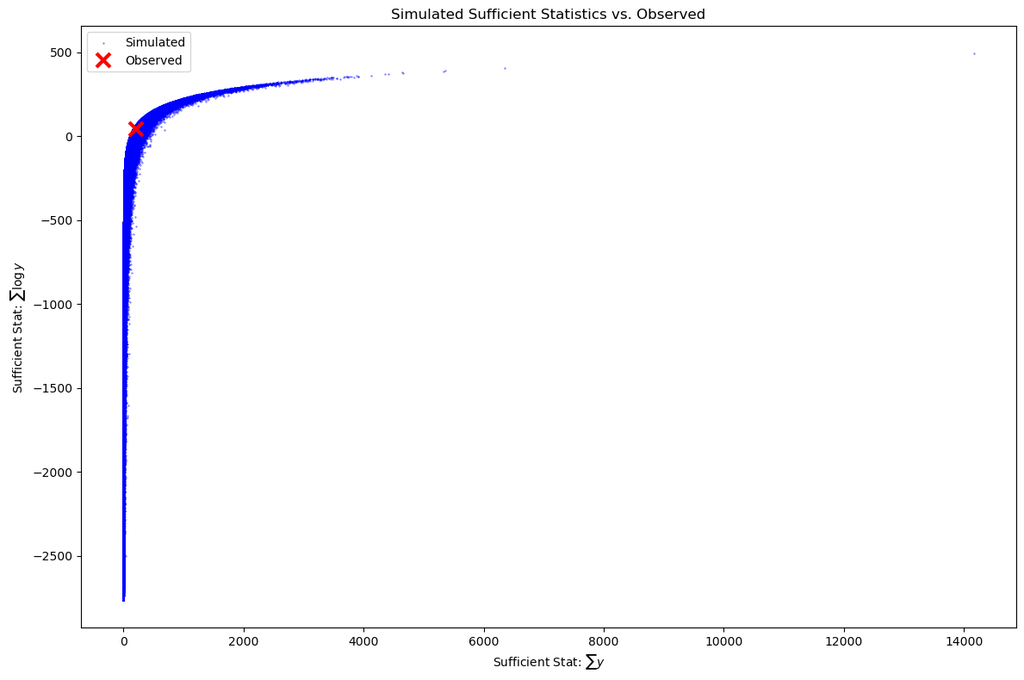

```python
# From your simulation
# suff_stats: columns = [alpha, beta, sum_y, sum_log_y]
sum_y_sim = suff_stats[:, 2]
sum_log_y_sim = suff_stats[:, 3]

# Observed data:
sum_y_obs = np.sum(data)
sum_log_y_obs = np.sum(np.log(data))

plt.figure(figsize=(12, 8))
plt.scatter(sum_y_sim, sum_log_y_sim, s=0.1, alpha=1, color='blue', label='Simulated')
plt.plot(sum_y_obs, sum_log_y_obs, 'rx', markersize=12, mew=3, label='Observed')

plt.xlabel(r'Sufficient Stat: $\sum y$')
plt.ylabel(r'Sufficient Stat: $\sum \log y$')
plt.title('Simulated Sufficient Statistics vs. Observed')
plt.legend()
plt.tight_layout()
plt.show()
```

### Standardization of Sufficient Statistics and Parameters

Given the instability encountered in training, **normalization becomes essential** for any neural network used in this setting.  
We standardize both the inputs (sufficient statistics) and outputs (parameters) to have zero mean and unit variance before splitting into training and validation sets.

This practice, already found helpful in previous experiments, helps mitigate issues arising from:

- Large differences in scale and units between $\sum y$ and $\sum \log y$,
- The wide dynamic range and skew in both statistics and parameters.

The normalization constants (means and standard deviations) must be saved for later use when making predictions or evaluating the trained model in the original parameter space.

```python
# Extract from suff_stats
X = suff_stats[:, 2:4].astype(np.float32)   # sum_y, sum_log_y
y = suff_stats[:, 0:2].astype(np.float32)   # alpha, beta

# Compute means and stds
X_mean = X.mean(axis=0)
X_std  = X.std(axis=0)
y_mean = y.mean(axis=0)
y_std  = y.std(axis=0)

# Standardize
X_standardized = (X - X_mean) / (X_std + 1e-8)
y_standardized = (y - y_mean) / (y_std + 1e-8)

# Use these for train/test splits:
from sklearn.model_selection import train_test_split
from torch.utils.data import TensorDataset
X_train, X_val, y_train, y_val = train_test_split(
    X_standardized, y_standardized, test_size=0.2, random_state=42)

train_dataset = TensorDataset(torch.tensor(X_train), torch.tensor(y_train))
val_dataset   = TensorDataset(torch.tensor(X_val), torch.tensor(y_val))

print("Means and stds for inverse transform (save these!):")
print("X_mean:", X_mean, "\nX_std:", X_std)
print("y_mean:", y_mean, "\ny_std:", y_std)
```

```
Means and stds for inverse transform (save these!):
X_mean: [  99.947464 -361.94046 ]
X_std: [173.90295 524.4686 ]
y_mean: [1.001081  1.0000893]
y_std: [1.0008966 1.0010566]
```

### Neural Network Posterior: Full-Covariance Normal Approximation

We parameterize our **amortized posterior** $q_\phi(\alpha, \beta \mid \text{suff. stats})$ as a full-covariance bivariate normal:

- The network takes standardized sufficient statistics ($\sum y$, $\sum \log y$) as input,
- Outputs the mean, log-standard deviations, and correlation for a bivariate normal over $(\alpha, \beta)$.

#### Architecture and Numerical Safety

- The final layer outputs: 2 means, 2 log-standard deviations, and 1 correlation parameter.
- We ensure **positivity** of standard deviations (via exponentiation and clamping) and **restrict correlation** to $(-0.99, 0.99)$ (via $\tanh$ and clamping).
- The negative log-likelihood (NLL) loss is computed for the predicted full-covariance normal, with additional guards against NaN/Inf values to avoid optimizer failure during training.

This design allows the network to model both the mean, marginal uncertainty, and the correlation structure in the posterior, while remaining robust to numerical instabilities that commonly arise in this context.

```python
class SuffStatsToFullCovNormal(nn.Module):
    """
    Maps sufficient statistics (sum_y, sum_log_y) to parameters of a full-covariance bivariate normal.
    Output: mean (2,), std (2,) [strictly positive], and correlation (1,) in (-0.99, 0.99)
    """
    def __init__(self, hidden_dim=32):
        super().__init__()
        self.net = nn.Sequential(
            nn.Linear(2, hidden_dim),
            nn.ReLU(),
            nn.Linear(hidden_dim, hidden_dim),
            nn.ReLU(),
            nn.Linear(hidden_dim, 5)  # 2 means, 2 log stds, 1 correlation
        )

    def forward(self, s):
        params = self.net(s)
        mu = params[:, :2]
        # Clamp log_std for numerical safety
        log_std = torch.clamp(params[:, 2:4], min=-10.0, max=3.0)  # exp(-10) ≈ 4e-5, exp(3) ≈ 20
        std = torch.exp(log_std)
        # Clamp correlation to (-0.99, 0.99)
        rho = torch.tanh(params[:, 4:5])
        rho = torch.clamp(rho, min=-0.99, max=0.99)
        return mu, std, rho

def full_cov_bivariate_normal_nll(targets, mu, std, rho, eps=1e-6):
    """
    Numerically safe NLL for a full-covariance bivariate normal.
    """
    x, y = targets[:, 0], targets[:, 1]
    mx, my = mu[:, 0], mu[:, 1]
    sx = torch.clamp(std[:, 0], min=eps)
    sy = torch.clamp(std[:, 1], min=eps)
    r = torch.clamp(rho[:, 0], min=-0.99, max=0.99)

    norm = 1.0 / (2 * np.pi * sx * sy * torch.sqrt(1 - r ** 2 + eps))
    z = ((x - mx) / sx) ** 2 + ((y - my) / sy) ** 2 - 2 * r * (x - mx) * (y - my) / (sx * sy)
    z = z / (2 * (1 - r ** 2) + eps)
    nll = -torch.log(norm + eps) + z

    # Replace inf/nan losses with a large constant to keep Optuna happy
    nll = torch.where(torch.isfinite(nll), nll, torch.tensor(1e6, device=nll.device))
    return nll.mean()
```

### Setting Up for Hyperparameter Optimization

To find good neural network hyperparameters, we use **Bayesian Optimization** with Optuna:

- The function `optuna_objective` defines a *search space* over hidden layer size and learning rate.
- For each trial, Optuna suggests values for these parameters, and the corresponding network and optimizer are constructed.

#### Why Bayesian Optimization?

Unlike grid or random search, **Bayesian Optimization** builds a probabilistic model of the objective function (validation loss here) and uses it to suggest promising hyperparameters efficiently. This is crucial for neural networks, where the optimal settings can be sensitive and expensive to discover by brute force.

> We’ll see the actual optimization and how the best values are selected in the next cell.

```python
# Define network constructor with parameterizable hidden dimension
def make_network(hidden_dim):
    return SuffStatsToFullCovNormal(hidden_dim=hidden_dim)

# Optuna search space function
def optuna_objective(trial):
    hidden_dim = trial.suggest_categorical('hidden_dim', [16, 32, 64, 128])
    learning_rate = trial.suggest_float('learning_rate', 1e-4, 1e-2, log=True)
    # Instantiate network with current trial's hidden_dim
    net = make_network(hidden_dim)
    # Set up optimizer
    optimizer = torch.optim.Adam(net.parameters(), lr=learning_rate)
    # Return everything needed downstream for training loop
    return net, optimizer, hidden_dim, learning_rate

# Example of how to call it (simulate one trial)
import optuna
trial = optuna.trial.FixedTrial({'hidden_dim': 64, 'learning_rate': 0.001})
net, optimizer, hidden_dim, learning_rate = optuna_objective(trial)
print(f"Network hidden dim: {hidden_dim}, Learning rate: {learning_rate}")
```

```
Network hidden dim: 64, Learning rate: 0.001
```

### Bayesian Optimization with Optuna: Automated Neural Network Tuning

Finding optimal neural network hyperparameters (like learning rate and hidden layer size) is notoriously difficult—manual tuning is slow and error-prone.  
**Bayesian Optimization** provides a principled, automated approach to this problem.

#### How Does Bayesian Optimization Work?

1. **Probabilistic Model:**  
   Bayesian optimization constructs a surrogate model (often a Gaussian process) for the objective function $f(\lambda)$, where $\lambda$ are the hyperparameters (e.g., learning rate, hidden dimension).  
   This model gives a posterior mean and variance for $f(\lambda)$ at every $\lambda$ tried so far, and predicts $f(\lambda)$ at new, untested $\lambda$.
2. **Acquisition Function:**  
   Given this model, an acquisition function $\alpha(\lambda)$ is defined (such as Expected Improvement or Upper Confidence Bound), quantifying how useful it would be to evaluate $f$ at a new $\lambda$.  
   Mathematically, for Expected Improvement: [ \alpha_{EI}(\lambda) = \mathbb{E}\left[ \max(0, f_{\text{best}} - f(\lambda)) \right] ] Optuna (by default) uses a Tree-structured Parzen Estimator (TPE) model as its surrogate.
3. **Optimization Loop:**  
   At each step, Optuna:
   - Uses the acquisition function to select new hyperparameters $\lambda^* = \arg\max_\lambda \alpha(\lambda)$,
   - Trains the neural network with $\lambda^*$ (for a few epochs),
   - Records the observed validation loss $f(\lambda^*)$,
   - Updates its surrogate model using the new $(\lambda^*, f(\lambda^*))$ pair.

#### What’s Happening in This Code?

- The objective function (`optuna_objective`) is run many times (trials), each with different hyperparameters.
- For each trial:
  - A new network is built and trained for a small number of epochs (here, just 5 for speed).
  - Validation loss is averaged over the held-out set and returned.
- **Optuna** maintains a record of all tested hyperparameters and their losses, and suggests new ones for each trial.
- After all trials, Optuna reports the hyperparameters that achieved the best validation loss.

#### Why Is This Useful?

- This method can efficiently find good settings, even for challenging, unstable neural net training.
- It adapts to the data: if some regions of the hyperparameter space look promising, it samples there more often.

> This enables us to robustly optimize our posterior network without extensive manual guesswork.

```python
from torch.utils.data import DataLoader, TensorDataset

# Assuming you have suff_stats: columns = [alpha, beta, sum_y, sum_log_y]
# X = sufficient stats: (sum_y, sum_log_y)
# y = targets: (alpha, beta)
# Use standardized sufficient stats and targets!
from sklearn.model_selection import train_test_split
X_train, X_val, y_train, y_val = train_test_split(
    X_standardized, y_standardized, test_size=0.2, random_state=42)

train_dataset = TensorDataset(torch.tensor(X_train), torch.tensor(y_train))
val_dataset   = TensorDataset(torch.tensor(X_val), torch.tensor(y_val))


def optuna_objective(trial):
    hidden_dim = trial.suggest_categorical('hidden_dim', [16, 32, 64, 128])
    learning_rate = trial.suggest_float('learning_rate', 1e-5, 1e-2, log=True)
    batch_size = 512  # Fixed for simplicity, can tune if you want

    net = SuffStatsToFullCovNormal(hidden_dim)
    optimizer = torch.optim.Adam(net.parameters(), lr=learning_rate)

    train_loader = DataLoader(train_dataset, batch_size=batch_size, shuffle=True)
    val_loader = DataLoader(val_dataset, batch_size=batch_size)

    n_epochs = 5  # Keep small for testing, increase for final runs

    # Training loop
    net.train()
    for epoch in range(n_epochs):
        for xb, yb in train_loader:
            optimizer.zero_grad()
            mu, std, rho = net(xb)
            loss = full_cov_bivariate_normal_nll(yb, mu, std, rho)
            loss.backward()
            optimizer.step()

    # Validation loss
    net.eval()
    val_losses = []
    with torch.no_grad():
        for xb, yb in val_loader:
            mu, std, rho = net(xb)
            loss = full_cov_bivariate_normal_nll(yb, mu, std, rho)
            val_losses.append(loss.item())
    val_loss = np.mean(val_losses)
    return val_loss

# Example: Create and run study
study = optuna.create_study(direction='minimize')
study.optimize(optuna_objective, n_trials=20)  # Try a small number first

print("Best params:", study.best_params)
print("Best loss:", study.best_value)
```

```
[I 2025-07-22 19:38:48,115] A new study created in memory with name: no-name-4632e61d-e4e2-4104-982c-a363e6ad9912
[I 2025-07-22 19:39:55,529] Trial 0 finished with value: -1.4962476235826303 and parameters: {'hidden_dim': 32, 'learning_rate': 0.0009339721908187226}. Best is trial 0 with value: -1.4962476235826303.
[I 2025-07-22 19:41:08,164] Trial 1 finished with value: 0.6048468703504108 and parameters: {'hidden_dim': 32, 'learning_rate': 3.5345939581201364e-05}. Best is trial 0 with value: -1.4962476235826303.
[I 2025-07-22 19:42:48,687] Trial 2 finished with value: 0.7417863586827007 and parameters: {'hidden_dim': 128, 'learning_rate': 1.6796505161824192e-05}. Best is trial 0 with value: -1.4962476235826303.
[I 2025-07-22 19:43:50,332] Trial 3 finished with value: -1.6151005172973398 and parameters: {'hidden_dim': 16, 'learning_rate': 0.005242138718140317}. Best is trial 3 with value: -1.6151005172973398.
[I 2025-07-22 19:45:21,315] Trial 4 finished with value: -1.9102268493388925 and parameters: {'hidden_dim': 128, 'learning_rate': 0.0006671838591852343}. Best is trial 4 with value: -1.9102268493388925.
[I 2025-07-22 19:46:18,766] Trial 5 finished with value: 0.07573776077145658 and parameters: {'hidden_dim': 16, 'learning_rate': 0.0001671558087461443}. Best is trial 4 with value: -1.9102268493388925.
[I 2025-07-22 19:47:15,572] Trial 6 finished with value: 1.5351783348166423 and parameters: {'hidden_dim': 32, 'learning_rate': 1.2185862781324904e-05}. Best is trial 4 with value: -1.9102268493388925.
[I 2025-07-22 19:48:47,400] Trial 7 finished with value: -1.026000000364945 and parameters: {'hidden_dim': 128, 'learning_rate': 6.410100784672704e-05}. Best is trial 4 with value: -1.9102268493388925.
[I 2025-07-22 19:49:47,561] Trial 8 finished with value: 0.7194819378730891 and parameters: {'hidden_dim': 16, 'learning_rate': 7.108694525292809e-05}. Best is trial 4 with value: -1.9102268493388925.
[I 2025-07-22 19:50:46,253] Trial 9 finished with value: -0.2525233943015337 and parameters: {'hidden_dim': 16, 'learning_rate': 0.00024739894985329077}. Best is trial 4 with value: -1.9102268493388925.
[I 2025-07-22 19:51:49,587] Trial 10 finished with value: -1.818574907682131 and parameters: {'hidden_dim': 64, 'learning_rate': 0.0013555991520856224}. Best is trial 4 with value: -1.9102268493388925.
[I 2025-07-22 19:52:58,188] Trial 11 finished with value: -1.906137766740511 and parameters: {'hidden_dim': 64, 'learning_rate': 0.0014959791944616834}. Best is trial 4 with value: -1.9102268493388925.
[I 2025-07-22 19:54:09,749] Trial 12 finished with value: -1.7294886923202164 and parameters: {'hidden_dim': 64, 'learning_rate': 0.0011025495791126304}. Best is trial 4 with value: -1.9102268493388925.
[I 2025-07-22 19:55:26,289] Trial 13 finished with value: -1.8648842757620165 and parameters: {'hidden_dim': 64, 'learning_rate': 0.005096783803181899}. Best is trial 4 with value: -1.9102268493388925.
[I 2025-07-22 19:57:05,875] Trial 14 finished with value: -1.828970239595379 and parameters: {'hidden_dim': 128, 'learning_rate': 0.0004660824801404273}. Best is trial 4 with value: -1.9102268493388925.
[I 2025-07-22 19:58:20,998] Trial 15 finished with value: -1.8999388681348328 and parameters: {'hidden_dim': 64, 'learning_rate': 0.002065701307741274}. Best is trial 4 with value: -1.9102268493388925.
[I 2025-07-22 20:00:04,694] Trial 16 finished with value: -1.7996174609264755 and parameters: {'hidden_dim': 128, 'learning_rate': 0.0005552464716970158}. Best is trial 4 with value: -1.9102268493388925.
[I 2025-07-22 20:01:46,659] Trial 17 finished with value: -1.7178875933522764 and parameters: {'hidden_dim': 128, 'learning_rate': 0.0025188283357255453}. Best is trial 4 with value: -1.9102268493388925.
[I 2025-07-22 20:03:01,926] Trial 18 finished with value: -1.6097418524115288 and parameters: {'hidden_dim': 64, 'learning_rate': 0.007286719883438894}. Best is trial 4 with value: -1.9102268493388925.
[I 2025-07-22 20:04:26,636] Trial 19 finished with value: -1.0352314877540558 and parameters: {'hidden_dim': 64, 'learning_rate': 0.00015508555650709828}. Best is trial 4 with value: -1.9102268493388925.
```

```
Best params: {'hidden_dim': 128, 'learning_rate': 0.0006671838591852343}
Best loss: -1.9102268493388925
```

### Full-Batch Neural Network Training and Loss Curves

With the best hyperparameters found by Bayesian optimization, we now **train the posterior neural network** for a large number of epochs (here, 3000) using full-batch gradient descent on the standardized training set.

#### Key Steps:

- At each epoch, the network predicts the parameters of the bivariate normal for all training data.
- The negative log likelihood (NLL) loss is computed and used to update the network weights.
- Validation loss is monitored at every epoch to track generalization and spot overfitting or instability.

#### Visualization:

- The first plot shows how both training and validation NLL evolve as training progresses.
- The second plot shows the same losses on a $\log_{10}$ scale, making it easier to observe progress over orders of magnitude (and to spot periods of instability or plateaus).

> Interpreting these curves is crucial for diagnosing issues like divergence, instability, or overfitting—especially in this challenging amortized inference setting.

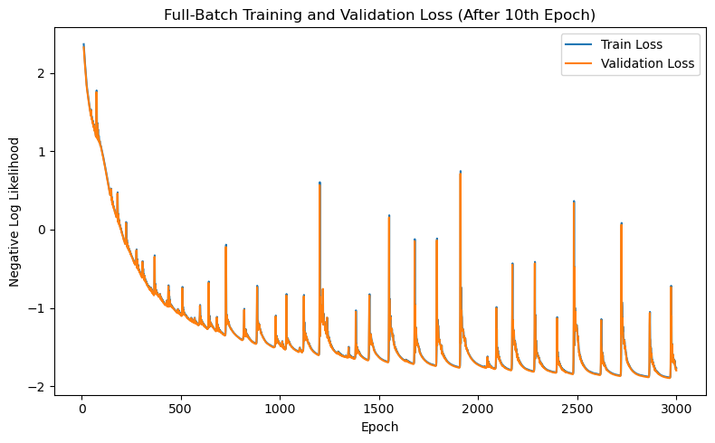

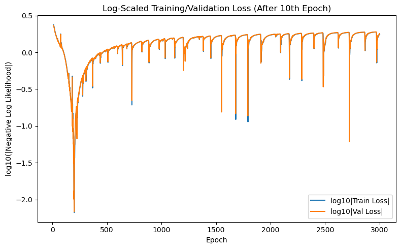

```python
import torch
import numpy as np
import matplotlib.pyplot as plt

# Hyperparameters from Optuna
hidden_dim = 128
learning_rate = 0.0006671838591852343
n_epochs = 3000  # Adjust as needed

X_train_full = torch.tensor(X_train)
y_train_full = torch.tensor(y_train)
X_val_full   = torch.tensor(X_val)
y_val_full   = torch.tensor(y_val)

net = SuffStatsToFullCovNormal(hidden_dim)
optimizer = torch.optim.Adam(net.parameters(), lr=learning_rate)

train_losses = []
val_losses = []

for epoch in range(n_epochs):
    net.train()
    optimizer.zero_grad()
    mu, std, rho = net(X_train_full)
    loss = full_cov_bivariate_normal_nll(y_train_full, mu, std, rho)
    loss.backward()
    optimizer.step()
    train_loss = loss.item()

    net.eval()
    with torch.no_grad():
        mu_val, std_val, rho_val = net(X_val_full)
        val_loss = full_cov_bivariate_normal_nll(y_val_full, mu_val, std_val, rho_val).item()

    train_losses.append(train_loss)
    val_losses.append(val_loss)

    # Print every 20th epoch, and always first and last
    if (epoch % 20 == 0) or (epoch == n_epochs - 1) or (epoch == 0):
        print(f"Epoch {epoch+1}/{n_epochs} | Train Loss: {train_loss:.4f} | Val Loss: {val_loss:.4f}")

# Plot only after 10th epoch
plot_from = 10  # Show from epoch 11 onwards
epochs = np.arange(plot_from + 1, n_epochs + 1)

plt.figure(figsize=(8, 5))
plt.plot(epochs, train_losses[plot_from:], label='Train Loss')
plt.plot(epochs, val_losses[plot_from:], label='Validation Loss')
plt.xlabel('Epoch')
plt.ylabel('Negative Log Likelihood')
plt.title('Full-Batch Training and Validation Loss (After 10th Epoch)')
plt.legend()
plt.tight_layout()
plt.show()

plt.figure(figsize=(8, 5))
plt.plot(epochs, np.log10(np.abs(train_losses[plot_from:])), label='log10|Train Loss|')
plt.plot(epochs, np.log10(np.abs(val_losses[plot_from:])), label='log10|Val Loss|')
plt.xlabel('Epoch')
plt.ylabel('log10(|Negative Log Likelihood|)')
plt.title('Log-Scaled Training/Validation Loss (After 10th Epoch)')
plt.legend()
plt.tight_layout()
plt.show()
```

### Comparing Marginal Posteriors: True vs Neural Network Approximation

The plots below compare the **true marginal posteriors** (black lines), computed via analytical grid integration, with the **neural network’s learned normal approximations** (red dashed lines) for both $\alpha$ and $\beta$.

#### Key Observations:

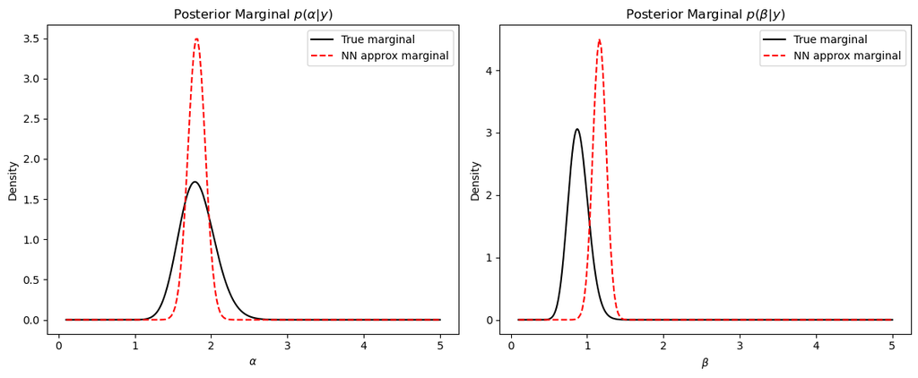

```python
import numpy as np
import matplotlib.pyplot as plt
import torch

# Standardize the observed stats
s_obs = np.array([sum_y_obs, sum_log_y_obs])
s_obs_standardized = (s_obs - X_mean) / (X_std + 1e-8)
s_obs_tensor = torch.tensor(s_obs_standardized, dtype=torch.float32).unsqueeze(0)  # shape (1,2)

# Evaluate approximate posterior (bivariate normal from NN)
net.eval()
with torch.no_grad():
    mu, std, rho = net(s_obs_tensor)
    mu = mu[0].numpy()
    std = std[0].numpy()
    rho = rho[0].item()

# De-standardize mean and std
mu_orig = mu * y_std + y_mean
std_orig = std * y_std

# Build the approximate bivariate normal for plotting marginals
from scipy.stats import multivariate_normal

# Fine grid for marginals
alpha_plot = np.linspace(alpha_grid.min(), alpha_grid.max(), 200)
beta_plot  = np.linspace(beta_grid.min(), beta_grid.max(), 200)

# For marginal of alpha: integrate over beta (actually, just fix beta at mean for bivariate normal)
approx_alpha_marginal = multivariate_normal(mean=mu_orig, cov=[[std_orig[0]**2, rho*std_orig[0]*std_orig[1]],
                                                               [rho*std_orig[0]*std_orig[1], std_orig[1]**2]]).pdf(
    np.stack([alpha_plot, np.full_like(alpha_plot, mu_orig[1])], axis=-1)
)
approx_alpha_marginal /= np.trapz(approx_alpha_marginal, alpha_plot)  # Normalize

# For marginal of beta: integrate over alpha (fix alpha at mean)
approx_beta_marginal = multivariate_normal(mean=mu_orig, cov=[[std_orig[0]**2, rho*std_orig[0]*std_orig[1]],
                                                              [rho*std_orig[0]*std_orig[1], std_orig[1]**2]]).pdf(
    np.stack([np.full_like(beta_plot, mu_orig[0]), beta_plot], axis=-1)
)
approx_beta_marginal /= np.trapz(approx_beta_marginal, beta_plot)  # Normalize

# --- PLOT ---

plt.figure(figsize=(12, 5))

plt.subplot(1, 2, 1)
plt.plot(alpha_grid, alpha_marginal, label='True marginal', color='black')
plt.plot(alpha_plot, approx_alpha_marginal, label='NN approx marginal', color='red', linestyle='--')
plt.xlabel(r'$\alpha$')
plt.ylabel('Density')
plt.title(r'Posterior Marginal $p(\alpha|y)$')
plt.legend()

plt.subplot(1, 2, 2)
plt.plot(beta_grid, beta_marginal, label='True marginal', color='black')
plt.plot(beta_plot, approx_beta_marginal, label='NN approx marginal', color='red', linestyle='--')
plt.xlabel(r'$\beta$')
plt.ylabel('Density')
plt.title(r'Posterior Marginal $p(\beta|y)$')
plt.legend()

plt.tight_layout()
plt.show()
```

### Scaling Up: Hyperparameter Search with Bayesian Optimization (TPE)

Encouraged by the earlier results, we now run a **more intensive hyperparameter optimization**—both increasing the number of trials (to 30) and dramatically increasing the number of epochs per trial (from 5 to 100).

#### **What’s Different?**

- **More hyperparameters:**  
  In addition to `hidden_dim` and `learning_rate` (optimized previously), we now also tune:
  - `weight_decay` (L2 regularization strength): crucial for controlling overfitting,
  - `grad_clip` (gradient clipping value): helps prevent instability and exploding gradients during training.
- **Much longer training:** Each candidate network is trained for 100 epochs (not just 5), so Optuna's decisions reflect longer-term performance, but at much greater computational cost.

#### **Tree-Structured Parzen Estimator (TPE) in Optuna**

Instead of grid search or random search, **Optuna** (by default) uses the Tree-Structured Parzen Estimator (TPE) as its sampler for Bayesian optimization.

##### **How does TPE work?**

- **Basic idea:**  
  TPE models the objective function $f(\lambda)$ (here, validation loss as a function of hyperparameters $\lambda$) using *two* non-parametric density estimators:
  - $l(\lambda)$: density of hyperparameters yielding “good” (i.e., low) loss,
  - $g(\lambda)$: density of hyperparameters yielding “bad” (i.e., higher) loss.
- **Sampling:**
  For each new trial, TPE chooses hyperparameters that maximize the ratio: $$ \text{score}(\lambda) = \frac{l(\lambda)}{g(\lambda)} $$ This is equivalent to maximizing the probability of improvement—sampling new candidates where good results are more likely, but the algorithm still explores broadly.
- **Tree-structured:**  
  TPE can handle conditional and categorical hyperparameters, making it very flexible for real-world (often non-continuous) search spaces.

##### **Why is this useful?**

- **Efficient exploration:** By focusing on areas of the hyperparameter space where good results are likely, TPE finds strong configurations with fewer expensive full-length trainings.
- **No early stopping:** In this setup, *all* trials are trained for the full 100 epochs—there’s no pruning or early termination, so total runtime is proportional to `n_trials × n_epochs`.

##### **Tradeoff:**

- This approach is **very time-consuming**: running 30 trials, each for up to 100 epochs, is a substantial computational investment.  
  However, it substantially increases the chance of finding robust, high-performing hyperparameters for these unstable networks.

> Optuna’s TPE sampler enables us to focus our search on promising hyperparameters while efficiently covering a complex space, even when each trial is computationally expensive.

```python
from torch.utils.data import DataLoader, TensorDataset

# Assuming you have suff_stats: columns = [alpha, beta, sum_y, sum_log_y]
# X = sufficient stats: (sum_y, sum_log_y)
# y = targets: (alpha, beta)
# Use standardized sufficient stats and targets!
from sklearn.model_selection import train_test_split
X_train, X_val, y_train, y_val = train_test_split(
    X_standardized, y_standardized, test_size=0.2, random_state=42)

train_dataset = TensorDataset(torch.tensor(X_train), torch.tensor(y_train))
val_dataset   = TensorDataset(torch.tensor(X_val), torch.tensor(y_val))

def optuna_objective(trial):
    hidden_dim = trial.suggest_categorical('hidden_dim', [128, 256])
    learning_rate = trial.suggest_float('learning_rate', 1e-6, 1e-3, log=True)
    weight_decay = trial.suggest_categorical('weight_decay', [0.0, 1e-8, 1e-7, 1e-6, 1e-5, 1e-4, 1e-3])
    grad_clip = trial.suggest_categorical('grad_clip', [1.0, 2.0, 3.0, 5.0, 10.0])

    # Full-batch tensors
    X_train_full = torch.tensor(X_train)
    y_train_full = torch.tensor(y_train)
    X_val_full   = torch.tensor(X_val)
    y_val_full   = torch.tensor(y_val)

    net = SuffStatsToFullCovNormal(hidden_dim)
    optimizer = torch.optim.Adam(net.parameters(), lr=learning_rate, weight_decay=weight_decay)

    n_epochs = 100

    for epoch in range(n_epochs):
        net.train()
        optimizer.zero_grad()
        mu, std, rho = net(X_train_full)
        loss = full_cov_bivariate_normal_nll(y_train_full, mu, std, rho)
        loss.backward()
        # Apply gradient clipping
        torch.nn.utils.clip_grad_norm_(net.parameters(), max_norm=grad_clip)
        optimizer.step()

    # Validation loss (full-batch)
    net.eval()
    with torch.no_grad():
        mu_val, std_val, rho_val = net(X_val_full)
        val_loss = full_cov_bivariate_normal_nll(y_val_full, mu_val, std_val, rho_val).item()
    return val_loss

# Example: Create and run study
import optuna
study = optuna.create_study(direction='minimize')
study.optimize(optuna_objective, n_trials=30)

print("Best params:", study.best_params)
print("Best loss:", study.best_value)
```

```
[I 2025-07-23 13:02:49,413] A new study created in memory with name: no-name-c705462f-1008-4fb8-bf49-ccf488b677cc
[I 2025-07-23 13:04:10,198] Trial 0 finished with value: 3.3404455184936523 and parameters: {'hidden_dim': 128, 'learning_rate': 3.377518166368459e-06, 'weight_decay': 1e-06, 'grad_clip': 10.0}. Best is trial 0 with value: 3.3404455184936523.
[I 2025-07-23 13:05:30,487] Trial 1 finished with value: 2.258617877960205 and parameters: {'hidden_dim': 128, 'learning_rate': 6.708050876288345e-05, 'weight_decay': 0.001, 'grad_clip': 3.0}. Best is trial 1 with value: 2.258617877960205.
[I 2025-07-23 13:06:51,670] Trial 2 finished with value: 2.1641159057617188 and parameters: {'hidden_dim': 128, 'learning_rate': 7.231025200822385e-05, 'weight_decay': 1e-08, 'grad_clip': 3.0}. Best is trial 2 with value: 2.1641159057617188.
[I 2025-07-23 13:08:09,630] Trial 3 finished with value: 1.528673768043518 and parameters: {'hidden_dim': 128, 'learning_rate': 0.0003605734348978033, 'weight_decay': 1e-06, 'grad_clip': 10.0}. Best is trial 3 with value: 1.528673768043518.
[I 2025-07-23 13:11:49,315] Trial 4 finished with value: 1.21254301071167 and parameters: {'hidden_dim': 256, 'learning_rate': 0.0003978404272935836, 'weight_decay': 1e-05, 'grad_clip': 3.0}. Best is trial 4 with value: 1.21254301071167.
[I 2025-07-23 13:15:44,981] Trial 5 finished with value: 2.1114425659179688 and parameters: {'hidden_dim': 256, 'learning_rate': 3.432092707723254e-05, 'weight_decay': 0.0, 'grad_clip': 2.0}. Best is trial 4 with value: 1.21254301071167.
[I 2025-07-23 13:17:05,738] Trial 6 finished with value: 2.866556167602539 and parameters: {'hidden_dim': 128, 'learning_rate': 2.987363886035999e-06, 'weight_decay': 1e-08, 'grad_clip': 10.0}. Best is trial 4 with value: 1.21254301071167.
[I 2025-07-23 13:18:30,024] Trial 7 finished with value: 1.449070930480957 and parameters: {'hidden_dim': 128, 'learning_rate': 0.00028504988399808806, 'weight_decay': 0.001, 'grad_clip': 2.0}. Best is trial 4 with value: 1.21254301071167.
[I 2025-07-23 13:19:58,261] Trial 8 finished with value: 2.68747615814209 and parameters: {'hidden_dim': 128, 'learning_rate': 1.9240867874649017e-05, 'weight_decay': 1e-07, 'grad_clip': 1.0}. Best is trial 4 with value: 1.21254301071167.
[I 2025-07-23 13:21:24,537] Trial 9 finished with value: 1.8882595300674438 and parameters: {'hidden_dim': 128, 'learning_rate': 0.00010609894799530106, 'weight_decay': 1e-08, 'grad_clip': 5.0}. Best is trial 4 with value: 1.21254301071167.
[I 2025-07-23 13:25:23,773] Trial 10 finished with value: 0.7067878246307373 and parameters: {'hidden_dim': 256, 'learning_rate': 0.0008847587370882888, 'weight_decay': 1e-05, 'grad_clip': 3.0}. Best is trial 10 with value: 0.7067878246307373.
[I 2025-07-23 13:29:10,148] Trial 11 finished with value: 0.8067682981491089 and parameters: {'hidden_dim': 256, 'learning_rate': 0.0008329094512352152, 'weight_decay': 1e-05, 'grad_clip': 3.0}. Best is trial 10 with value: 0.7067878246307373.
[I 2025-07-23 13:33:05,041] Trial 12 finished with value: 0.6238833069801331 and parameters: {'hidden_dim': 256, 'learning_rate': 0.0008930320315253527, 'weight_decay': 1e-05, 'grad_clip': 3.0}. Best is trial 12 with value: 0.6238833069801331.
[I 2025-07-23 13:36:49,269] Trial 13 finished with value: 0.8487407565116882 and parameters: {'hidden_dim': 256, 'learning_rate': 0.0006752102924609494, 'weight_decay': 0.0001, 'grad_clip': 3.0}. Best is trial 12 with value: 0.6238833069801331.
[I 2025-07-23 13:40:30,798] Trial 14 finished with value: 1.4097485542297363 and parameters: {'hidden_dim': 256, 'learning_rate': 0.00016280138475805155, 'weight_decay': 1e-05, 'grad_clip': 5.0}. Best is trial 12 with value: 0.6238833069801331.
[I 2025-07-23 13:44:19,078] Trial 15 finished with value: 2.7081074714660645 and parameters: {'hidden_dim': 256, 'learning_rate': 1.4272306127528461e-05, 'weight_decay': 1e-05, 'grad_clip': 1.0}. Best is trial 12 with value: 0.6238833069801331.
[I 2025-07-23 13:47:53,733] Trial 16 finished with value: 0.789594292640686 and parameters: {'hidden_dim': 256, 'learning_rate': 0.0008192744451473886, 'weight_decay': 1e-05, 'grad_clip': 3.0}. Best is trial 12 with value: 0.6238833069801331.
[I 2025-07-23 13:51:28,495] Trial 17 finished with value: 2.7966463565826416 and parameters: {'hidden_dim': 256, 'learning_rate': 1.1564236594580612e-06, 'weight_decay': 0.0, 'grad_clip': 3.0}. Best is trial 12 with value: 0.6238833069801331.
[I 2025-07-23 13:55:12,418] Trial 18 finished with value: 1.4402918815612793 and parameters: {'hidden_dim': 256, 'learning_rate': 0.00021417836824506563, 'weight_decay': 0.0001, 'grad_clip': 3.0}. Best is trial 12 with value: 0.6238833069801331.
```

[output cut: 11 more lines]

```
Best params: {'hidden_dim': 256, 'learning_rate': 0.0009662513850782904, 'weight_decay': 1e-05, 'grad_clip': 3.0}
Best loss: 0.3758498728275299
```

### Saving the Optuna Study

Since large-scale hyperparameter searches can take a long time, it's often necessary to save your progress and resume later.  
This is the recommended code to **save the Optuna study** to disk, so you don't lose results if you have to stop and restart your work.

```python
import joblib

# Save the study object to a file (choose your filename)
joblib.dump(study, "optuna_study.pkl")

print("Study saved to optuna_study.pkl")
```

```
Study saved to optuna_study.pkl
```

### Final Training with Optimized Hyperparameters

Using the best hyperparameters found from the more exhaustive search:

- `hidden_dim = 256` (the network benefits from increased capacity over the earlier value of 128),
- `learning_rate ≈ 9.7 \times 10^{-4}` (remarkably close to the optimal value found in the initial shorter runs),
- Additional regularization and gradient clipping settings from the latest study.

**Notable observations:**

As before, we track and plot both training and validation loss curves, including their log-transformed values, to assess stability and convergence across this much longer training period.

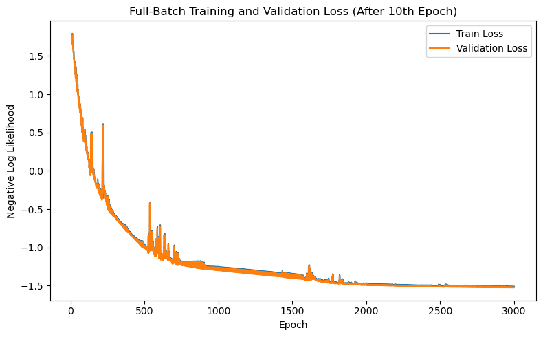

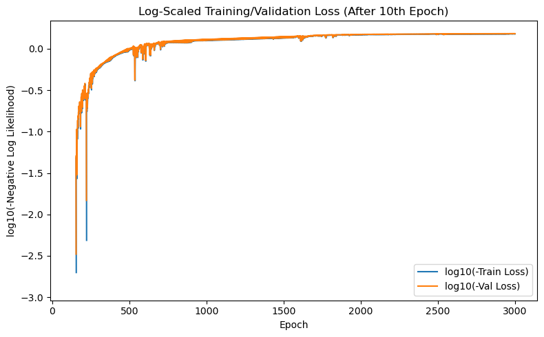

```python
### import torch
import numpy as np
import matplotlib.pyplot as plt

# Params from Optuna
hidden_dim = 256
learning_rate = 0.0009662513850782904
weight_decay = 1e-5
grad_clip = 3.0
n_epochs = 3000  # You can increase for final training

# Data as full-batch tensors
X_train_full = torch.tensor(X_train)
y_train_full = torch.tensor(y_train)
X_val_full   = torch.tensor(X_val)
y_val_full   = torch.tensor(y_val)

# Model, optimizer, scheduler
net = SuffStatsToFullCovNormal(hidden_dim)
optimizer = torch.optim.Adam(net.parameters(), lr=learning_rate, weight_decay=weight_decay)
scheduler = torch.optim.lr_scheduler.ReduceLROnPlateau(optimizer, patience=10, factor=0.9, verbose=True)

train_losses = []
val_losses = []

for epoch in range(n_epochs):
    net.train()
    optimizer.zero_grad()
    mu, std, rho = net(X_train_full)
    loss = full_cov_bivariate_normal_nll(y_train_full, mu, std, rho)
    loss.backward()
    torch.nn.utils.clip_grad_norm_(net.parameters(), max_norm=grad_clip)
    optimizer.step()
    train_loss = loss.item()

    net.eval()
    with torch.no_grad():
        mu_val, std_val, rho_val = net(X_val_full)
        val_loss = full_cov_bivariate_normal_nll(y_val_full, mu_val, std_val, rho_val).item()

    scheduler.step(val_loss)
    train_losses.append(train_loss)
    val_losses.append(val_loss)

    if (epoch % 1 == 0) or (epoch == n_epochs - 1) or (epoch == 0):
        print(f"Epoch {epoch+1}/{n_epochs} | Train Loss: {train_loss:.4f} | Val Loss: {val_loss:.4f} | LR: {optimizer.param_groups[0]['lr']:.2e}")

# Plotting losses
plot_from = 10  # Only plot after the 10th epoch
epochs = np.arange(plot_from + 1, n_epochs + 1)

plt.figure(figsize=(8, 5))
plt.plot(epochs, train_losses[plot_from:], label='Train Loss')
plt.plot(epochs, val_losses[plot_from:], label='Validation Loss')
plt.xlabel('Epoch')
plt.ylabel('Negative Log Likelihood')
plt.title('Full-Batch Training and Validation Loss (After 10th Epoch)')
plt.legend()
plt.tight_layout()
plt.show()

plt.figure(figsize=(8, 5))
plt.plot(epochs, np.log10(-np.array(train_losses[plot_from:])), label='log10(-Train Loss)')
plt.plot(epochs, np.log10(-np.array(val_losses[plot_from:])), label='log10(-Val Loss)')
plt.xlabel('Epoch')
plt.ylabel('log10(-Negative Log Likelihood)')
plt.title('Log-Scaled Training/Validation Loss (After 10th Epoch)')
plt.legend()
plt.tight_layout()
plt.show()
```

```python
# Confirm model is still usable
net.eval()
with torch.no_grad():
    mu_val, std_val, rho_val = net(X_val_full)
    val_loss = full_cov_bivariate_normal_nll(y_val_full, mu_val, std_val, rho_val).item()
print(f"Validation Loss after interrupt: {val_loss:.4f}")
```

```
Validation Loss after interrupt: -1.6598
```

```python
torch.save(net.state_dict(), "net_interrupted.pt")
print("Model saved to 'net_interrupted.pt'")
```

```
Model saved to 'net_interrupted.pt'
```

### Effect of Further Hyperparameter Optimization: Posterior Marginal Comparison

The plots below show the **marginal posteriors** from the newly trained neural network compared to the analytical ground truth.

#### Takeaway

- Even in this challenging inference problem, **further hyperparameter optimization alone leads to tangible gains**, especially in the quality and calibration of the posterior for $\alpha$.
- The results reinforce the value of rigorous hyperparameter search, and suggest there may still be room for further improvement.

> Continuous tuning is often rewarded, even for amortized inference where instability is common and improvements are not always uniform across all parameters.

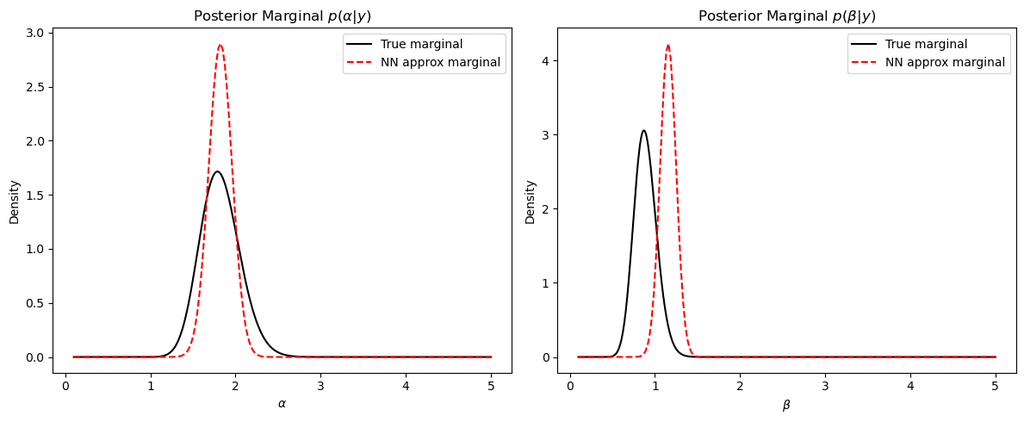

```python
import numpy as np
import matplotlib.pyplot as plt
import torch

# Standardize the observed stats
s_obs = np.array([sum_y_obs, sum_log_y_obs])
s_obs_standardized = (s_obs - X_mean) / (X_std + 1e-8)
s_obs_tensor = torch.tensor(s_obs_standardized, dtype=torch.float32).unsqueeze(0)  # shape (1,2)

# Evaluate approximate posterior (bivariate normal from NN)
net.eval()
with torch.no_grad():
    mu, std, rho = net(s_obs_tensor)
    mu = mu[0].numpy()
    std = std[0].numpy()
    rho = rho[0].item()

# De-standardize mean and std
mu_orig = mu * y_std + y_mean
std_orig = std * y_std

# Build the approximate bivariate normal for plotting marginals
from scipy.stats import multivariate_normal

# Fine grid for marginals
alpha_plot = np.linspace(alpha_grid.min(), alpha_grid.max(), 200)
beta_plot  = np.linspace(beta_grid.min(), beta_grid.max(), 200)

# For marginal of alpha: integrate over beta (actually, just fix beta at mean for bivariate normal)
approx_alpha_marginal = multivariate_normal(mean=mu_orig, cov=[[std_orig[0]**2, rho*std_orig[0]*std_orig[1]],
                                                               [rho*std_orig[0]*std_orig[1], std_orig[1]**2]]).pdf(
    np.stack([alpha_plot, np.full_like(alpha_plot, mu_orig[1])], axis=-1)
)
approx_alpha_marginal /= np.trapz(approx_alpha_marginal, alpha_plot)  # Normalize

# For marginal of beta: integrate over alpha (fix alpha at mean)
approx_beta_marginal = multivariate_normal(mean=mu_orig, cov=[[std_orig[0]**2, rho*std_orig[0]*std_orig[1]],
                                                              [rho*std_orig[0]*std_orig[1], std_orig[1]**2]]).pdf(
    np.stack([np.full_like(beta_plot, mu_orig[0]), beta_plot], axis=-1)
)
approx_beta_marginal /= np.trapz(approx_beta_marginal, beta_plot)  # Normalize

# --- PLOT ---

plt.figure(figsize=(12, 5))

plt.subplot(1, 2, 1)
plt.plot(alpha_grid, alpha_marginal, label='True marginal', color='black')
plt.plot(alpha_plot, approx_alpha_marginal, label='NN approx marginal', color='red', linestyle='--')
plt.xlabel(r'$\alpha$')
plt.ylabel('Density')
plt.title(r'Posterior Marginal $p(\alpha|y)$')
plt.legend()

plt.subplot(1, 2, 2)
plt.plot(beta_grid, beta_marginal, label='True marginal', color='black')
plt.plot(beta_plot, approx_beta_marginal, label='NN approx marginal', color='red', linestyle='--')
plt.xlabel(r'$\beta$')
plt.ylabel('Density')
plt.title(r'Posterior Marginal $p(\beta|y)$')
plt.legend()

plt.tight_layout()
plt.show()
```

## Conclusion

In this notebook, we demonstrated how hyperparameter optimization is critical for stable and accurate neural posterior inference, even when using sufficient statistics for a simple Gamma model.

Initially, we applied **simple Bayesian optimization** with Optuna (using its default TPE sampler), and found that even limited searches over a small number of epochs produced hyperparameters that transferred well to related problems—specifically, these hyperparameters performed even better in my earlier notebook using summary statistics (mean and variance). This highlights that effective optimization strategies can have value beyond a single modeling setup.

Looking ahead, a natural next step would be to try **Hyperband** or other pruning-based optimizers. Unlike standard Bayesian optimization, Hyperband aggressively stops unpromising trials early, reallocating computational effort to the most promising candidates. This could be particularly advantageous when running each trial for many epochs or when exploring larger or more complex neural architectures.

However, one must also acknowledge the **substantial computational cost**:  
Running Bayesian optimization for even 30 trials at 100 (or more) epochs each is resource-intensive. This experience has convinced me that it is best to run an optimizer **once, with a sufficiently large number of epochs per trial**, and to be deliberate in selecting which hyperparameters (and which value ranges) to search over. While there is no formula for this—intuition, prior results, and diagnostic plots remain indispensable—this approach can prevent the need for repeated, expensive searches in the future.

Ultimately, these experiments reaffirmed that even in apparently simple settings, **careful hyperparameter search is a necessary part of modern Bayesian neural inference**—and getting it right is both a computational and scientific challenge.